# Identifying selection

Definition and application of approaches noted in [Going global by adapting local: A review of recent human adaptation](https://doi.org/10.1126/science.aaf5098)

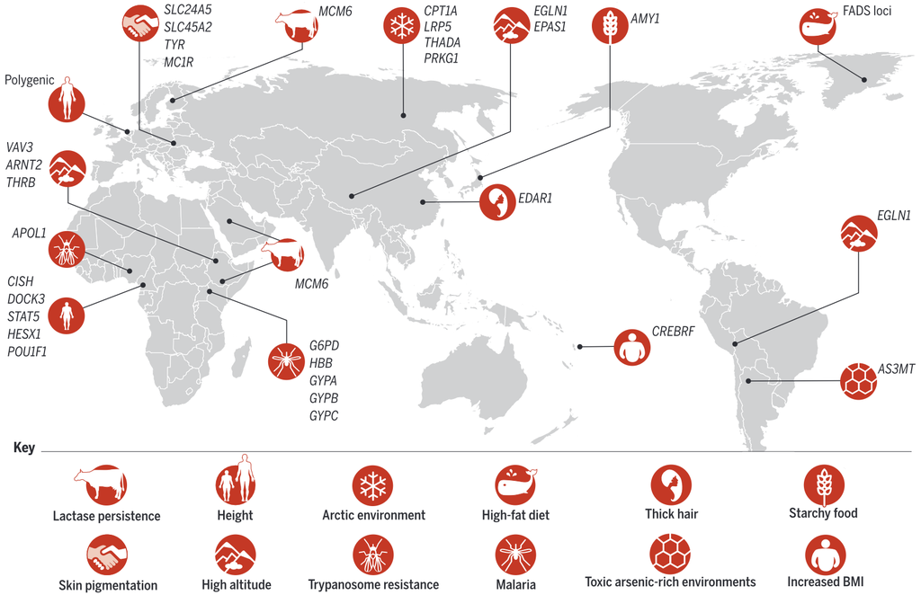

Human local adaptations

### Approaches:

- $\mathrm{F_{ST}}$
- PBS: Population Branch Statistic
- LSBL: Locus-Specific Branch Length
- EHH: Extended haplotype homozygosity
  - iHS: Integrated haplotype statistic
  - XP-EHH: Cross-population EHH

### Terms:

- Hitchhiking: An increase in proximate variant expression due to selection for a haplotype
- Selective sweep: Decline in genetic diversity due to the spread or fixation of a selected-for variant

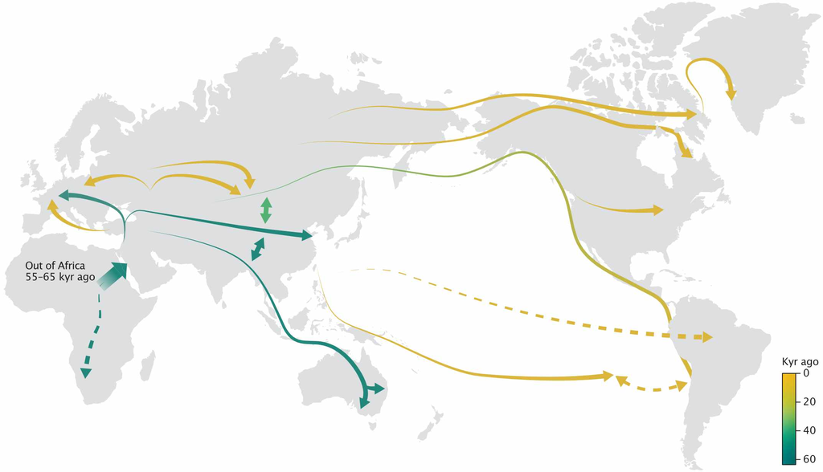

**Fig. 1 ([source](https://www.nature.com/articles/nature21347)).** The history of human migrations.

## Fixation index (F<sub>ST</sub>)

- $\mathbf{H_T}$: The total frequency of heterozygotes
- $\mathbf{mean(H_S)}$: The mean of frequencies of heterozygotes of each subgroup
- where $H = 2pq$, and $p$ and $q$ are the frequencies of the two alleles at a site

$$\textrm{F}_{ST} = \frac{H_T - \textrm{mean}(H_S)}{H_T}$$

- $\mathrm{F_{ST}} = 0$: No variation among subpopulations
- $\mathrm{F_{ST}} = 1$: Variation exclusively among subpopulations

Reference: [Review](https://pubmed.ncbi.nlm.nih.gov/19687804/)

From the 1000 Genomes Project:

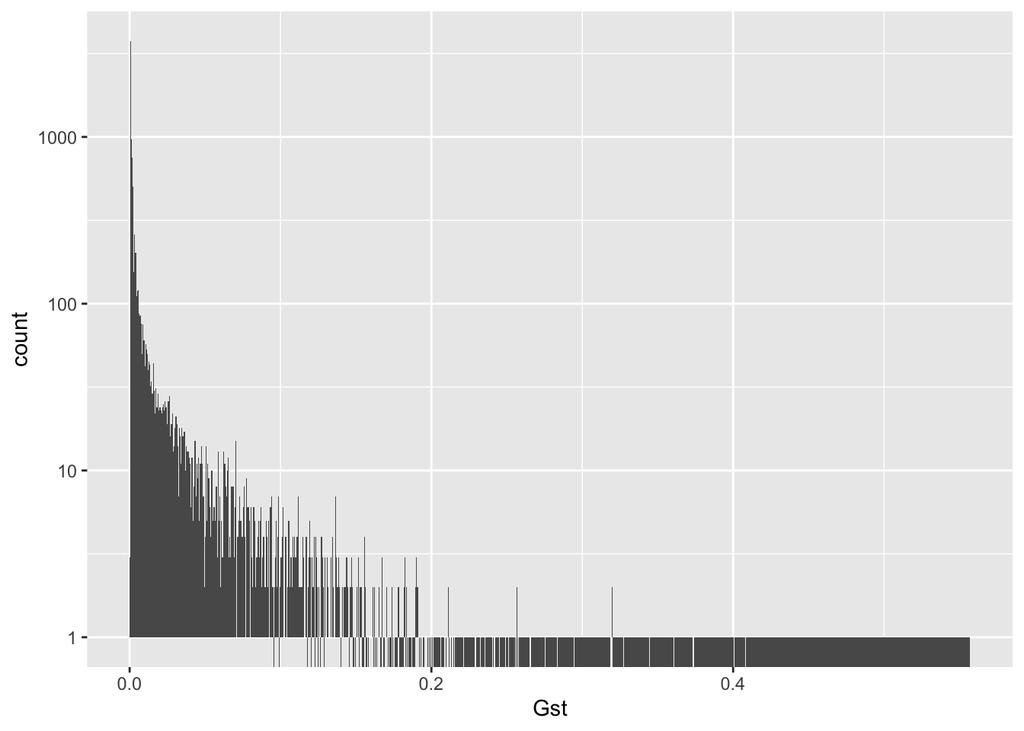

```r
vcf <- read.vcfR(file = "random_variable_sites.vcf.gz", verbose=FALSE)

metadata <- read.table("integrated_call_samples.txt",
                       header = TRUE)

pop_labels <- as.factor(metadata$superpop)

gst_results <- genetic_diff(vcf, pop_labels) %>%
  arrange(-Gst)

ggplot(data = gst_results,
       aes(x = Gst)) +
  geom_histogram(bins=1000) +
  scale_y_continuous(trans="log10")
```

(Almost) exponential decay, with most genes below a 1% $\mathrm{F_{ST}}$

### Analyzing G<sub>ST</sub> hits in [**GGV**](https://popgen.uchicago.edu/ggv/?data=%221000genomes%22)

```r
gst_results[1, ]
```

```
##   CHROM      POS    Hs_AFR    Hs_AMR    Hs_EAS     Hs_EUR    Hs_SAS        Ht
## 1 chr21 17753762 0.3537087 0.2017499 0.1326531 0.02931902 0.0400634 0.3650242
##   n_AFR n_AMR n_EAS n_EUR n_SAS      Gst     Htmax   Gstmax  Gprimest
## 1  1320   694  1008  1008   978 0.557253 0.8286973 0.804979 0.6922578
```

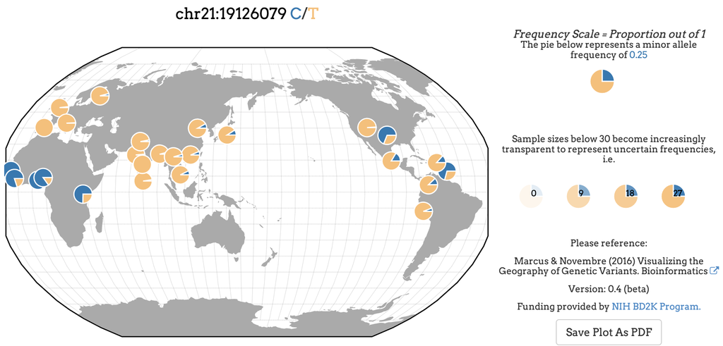

**Fig. 5.** Allele frequencies of our top G<sub>ST</sub> hit.

## Population branch statistic (PBS)

For distances ($\mathbf{T}$) given pairwise $\mathbf{F_{ST}}$:

$$T = -\mathrm{ln}(1 - \textrm{F}_{ST})$$

$$\textrm{PBS} = \frac{\textrm{T}_{AB} + \textrm{T}_{AC} -
\textrm{T}_{BC}}{2}$$

#### Explanation (of T: drift time):

- $F_{ST}$ measures the **fractional reduction of heterozygosity within subpopulations relative to total heterozygosity**:

  $$F_{ST} = \frac{H_T -
  H_S}{H_T}$$

(Under pure drift) within-population heterozygosity decays exponentially:

$$H_t = H_0 e^{-t/(2N_e)}$$
$$F_{ST} \approx 1 - e^{-t/(2N_e)}$$

$$T = -\ln(1 - F_{ST})$$

yields an additive quantity proportional to time over $2N_e$, which behaves like a **branch length (drift time)** and is used in the Population Branch Statistic (PBS).

### PBS Example: Allele origin among three populations

Using: [Tucci, S. et al. (2018). Evolutionary history and adaptation of a human pygmy population of Flores Island, Indonesia.](https://science.sciencemag.org/content/361/6401/511.abstract).

Flores Island was home to fossils of the archaic hominin species **Homo floresiensis**, also called “hobbits” because their skeletons are 3 ft. tall. It’s thought that *H. floresiensis* lived there until just 40k-30k years ago, overlapping with modern humans.

This study collected samples from individuals who currently live on Flores Island and scanned their genomes for evidence of natural selection. They calculated **PBS** between:

- The Rampasasa (**RPS**) population from Flores
- A Han Chinese (**CHB**) population
- A Melanesian population from Papua New Guinea (**PNG**)

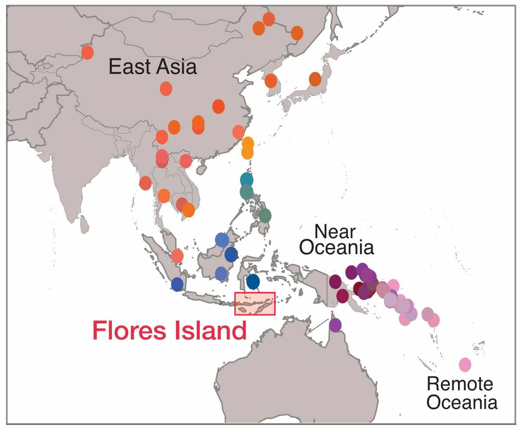

**Fig. 7.** Distribution of populations used in Tucci et al.

Load pre-calculated pairwise $\textrm{F}_{ST}$ between the Rampasasa, Han Chinese, and Papua New Guinea populations (for chromosome 11). Rows mark SNPs at ‘pos’, which are essentially unique in this data.

```r
fst_results <- read.table("fst_results.txt.gz", header = TRUE)
head(fst_results)
```

```
##   chr       pos    rps.af    chb.af    png.af fst.rps.chb fst.rps.png
## 1  11 100001950 0.1666670 0.0145631 0.0428571  0.32524800   0.0845486
## 2  11 100003476 0.0555556 0.0339806 0.1000000 -0.01078610  -0.0118052
## 3  11 100004351 0.1111110 0.0485437 0.1142860  0.05945300  -0.0322152
## 4  11 100005864 0.6111110 0.6553400 0.4285710 -0.02752900   0.0520164
## 5  11 100006486 0.8333330 0.7766990 0.7571430  0.00768713  -0.0119055
## 6  11 100006861 0.5000000 0.3834950 0.2285710  0.05413630   0.1807550
##   fst.png.chb
## 1  0.00465910
## 2  0.03640770
## 3  0.02896550
## 4  0.11842600
## 5 -0.00951234
## 6  0.06338550
```

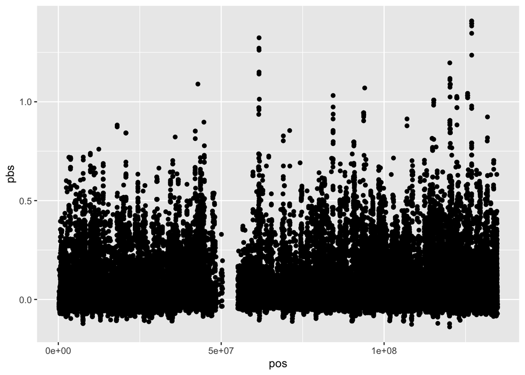

```r
pbs <- fst_results %>%
  mutate(T_rps_chb = -log(1 - fst.rps.chb),
         T_rps_png = -log(1 - fst.rps.png),
         T_png_chb = -log(1 - fst.png.chb)) %>%
  mutate(pbs = ((T_rps_png + T_rps_chb) - (T_png_chb)) / 2) %>%
  arrange(-pbs)

ggplot(data = pbs,
       aes(x = pos, y = pbs)) +
  geom_point()
```

As evidence of positive selection, we are interested in both the height of the peaks in the plot, as well as the number of SNPs that comprise each peak (which is a proxy for haplotype length).

#### Top PBS hits

Use the [UCSC Genome Browser](https://genome.ucsc.edu/cgi-bin/hgTracks?db=hg19) to look up the top two PBS peaks. (We’re using the **hg19** browser here because this data was generated with the hg19 reference genome.)

The top chr11 peak doesn’t seem to overlap with any genes, but is closest to *KIRREL3*.

The second chr11 peak overlaps with the fatty acid desaturase gene cluster (*FADS1*, *FADS2*, and *FADS3*), which have [previously been implicated](https://science.sciencemag.org/content/349/6254/1343.short) as targets of independent episodes of positive selection in human populations.

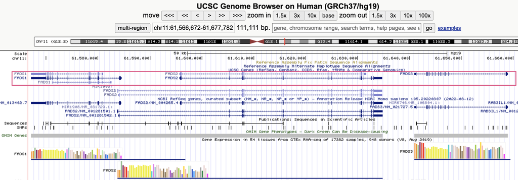

**Fig. 8.** The *FADS* gene cluster around the second PBS peak.

#### Plotting PBS trees

Another useful way to visualize PBS is by comparing trees for the top PBS outliers to the genome-wide average tree. Run the code blocks below to plot these trees:

```
## Average angle change [1] 0.333333333333333
```

```
## Average angle change [2] 0
```

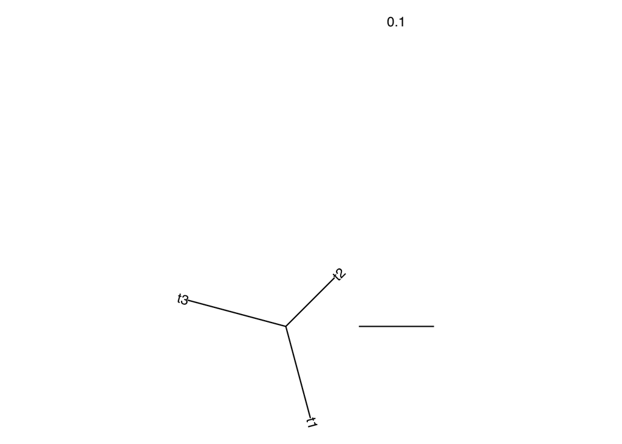

```r
# create average tree
tr_mean <- rtree(n = 3,
                 rooted = FALSE,
                 br = c(mean(pbs$T_rps_png),
                        mean(pbs$T_rps_chb),
                        mean(pbs$T_png_chb)))

# plot average tree
ggtree(tr_mean, layout = "daylight") +
  geom_treescale(width = 0.1) +
  geom_tiplab(label = c("RPS", "PNG", "CHB"))
```

```
## Average angle change [1] 0.333333333333333
```

```
## Average angle change [2] 0
```

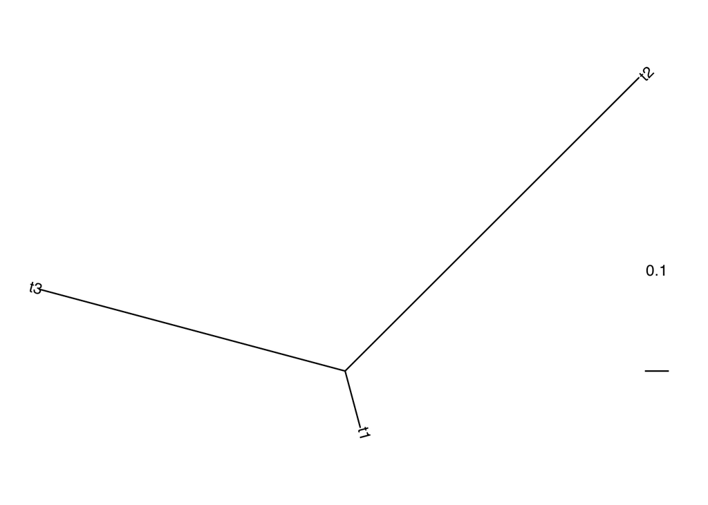

```r
# create tree for top snp
tr_top <- rtree(n = 3,
                rooted = FALSE,
                br = c(pbs[1,]$T_rps_png,
                       pbs[1,]$T_rps_chb,
                       pbs[1,]$T_png_chb))

ggtree(tr_top, layout = "daylight") +
  geom_treescale(width = 0.1) +
  geom_tiplab(label = c("RPS", "PNG", "CHB"))
```

## LSBL: Locus-Specific Branch Length

The 1st Taylor series term (around 0) of drift-time $\mathrm{T}$ gives $\mathrm{F_{ST}}$

$$- \ln(1 - F_{ST}) \approx
F_{ST}$$
Justifying this approximation, most human $\mathrm{F_{ST}}$ are small (below 1%, generally <15%)

$$LSBL_i = \frac{1}{2} \left( F_{ST}^{i,j}
+ F_{ST}^{i,k} - F_{ST}^{j,k} \right)$$

## Extended haplotype homozygosity

EHH captures long haplotypes that result from a selective sweep but, unlike prior statistics, can discriminate:

- Selection, subpopulation-specific, would manifest as a high and local PBS/FST
- Random fixation (from genetic drift), subpopulation-specific, would manifest in high PBS/FST
- Background (linked purifying) selection generates AF variation, inflating PBS/FST: removal of neutral alleles linked to deleterious mutations
- Subpopulation structures (non-random mating, founder events) inflate FST/PBS (broad, detectable by clustering)

**Extended haplotype homozygosity (EHH)** is the probability that any two haplotypes in a population are homozygous at SNPs in specific genomic region. EHH is elevated in regions under historical selection relative to drift.

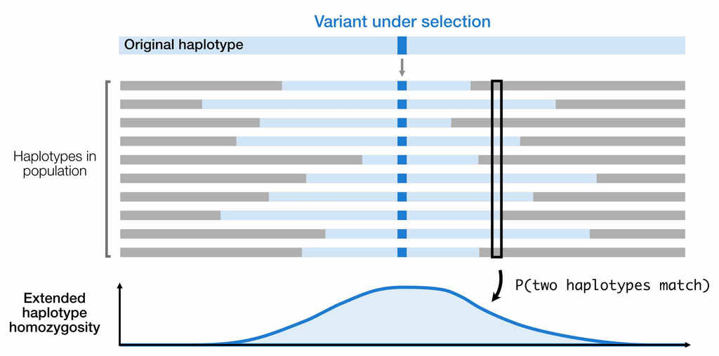

**Fig. 9.** EHH measures how likely two haplotypes are to carry the same variant at a given location – a signature that we expect recent selection to exaggerate.

### EHH: Phylogeny-like plot

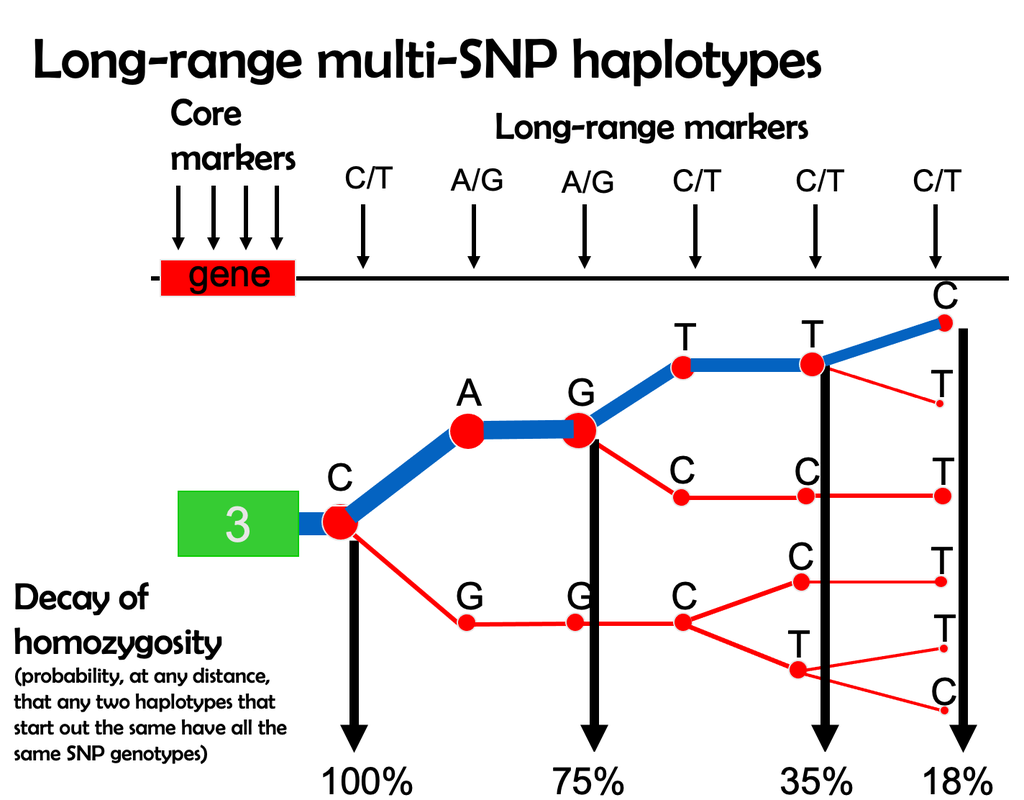

**Fig. 10 (from David Reich).** Overrepresentation of the blue haplotype indicates extreme EHH, a possible signature of selection.

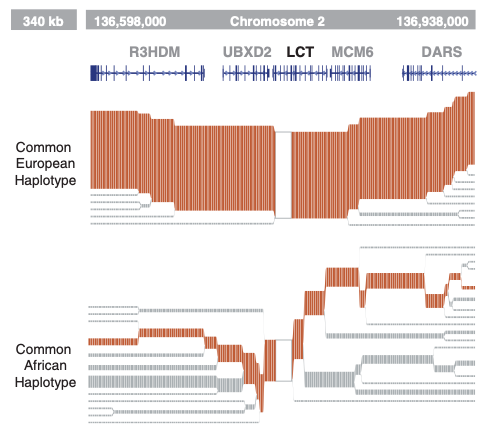

**Fig. 11.** EHH calculated for the lactase locus (CEU population of 1000 Genomes)

## iHS (Integrated haplotype statistic)

The **integrated haplotype statistic (iHS)** is ln of derived divided by ancestral EHH curve integrals.

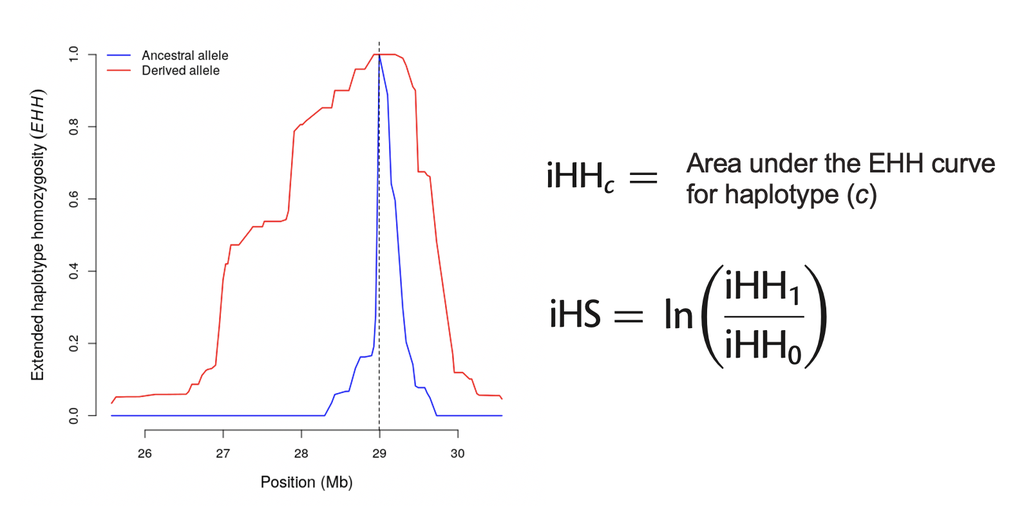

**Fig. 12.** Comparing the EHH of haplotypes carrying the derived and ancestral alleles to calculate iHS.

## XP-EHH is iHS between contemporaneous populations

### The PopHuman browser

EHH and iHS exist genome-wide for all of the populations in the 1000 Genomes dataset, available from the [**PopHuman browser**](https://pophuman.uab.cat/).

Ex: Look up the lactase (*LCT*) gene in the search bar, and then click `Select tracks` in the upper left-hand corner to choose:

- **iHS** for the CEU (European) population
- **pi** for the CEU population. This is a measure of nucleotide diversity, which we expect to be low in a region under historical selection

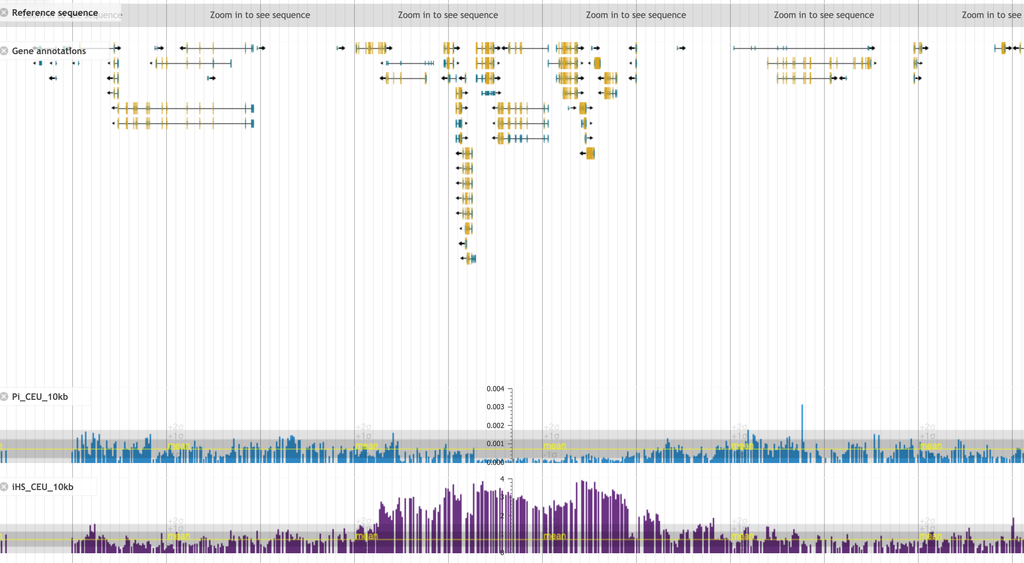

**Fig. 13.** iHS and $\pi$ in the *LCT* region.

Note that if we compare both of these statistics to the genome-wide mean (yellow lines), we can see how dramatically they deviate from expectations in this genomic region.